# Harmonic Direction Finding Radar - RF Photonics - University of Maine

# RF Photonics

## Harmonic Direction Finding Radar

**Tracking Juvenile Wood Frogs With Harmonic Radar (2010 – 2013)**

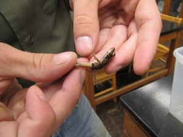

Juvenile wood frog with harmonic tag attached to its waist.

[figure not shown]

5.8 GHz / 11.6 GHz harmonic direction finding radar instrument.

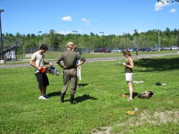

Graduate and undergraduate students field testing the HDF radar instrument.

Wood frogs are a source of nutrients for other wildlife, hence their health and survival determines the health of the forest. Juvenile frogs have a length of less then 4 centimeters and a weight of approximately 0.6 grams, making battery powered tag applications impractical. A passive tag using a Schottky diode was developed, along with a 5.8 GHz / 11.6 GHz harmonic direction finding radar, to track juvenile wood frogs in the field.

This research was been funded by the National Science Foundation.

- Faculty: Nuri Emanetoglu (ECE), Herbert Aumann (ECE), Malcolm Hunter (WLE)
- Graduate students: Brittany Cline
- Undergraduate students: Evan Kus, Matthew Krenik, Margaret Thompson

*Publications*

- “Application of Huygens’ Principle to a Dual Frequency Constant Beamwidth Reflector Operating in the Focused Near-Field”, H. Aumann, N.W. Emanetoglu, *36th Annual Symposium of the Antenna Measurement Techniques Association*, Tuscon, AZ, Oct. 12-17, 2014
- “A Constant Beamwidth Reflector Antenna for a Harmonic Radar Operating in the Near-Field”, H. Aumann, N.W. Emanetoglu, *16th Intl. on Antenna Tech. and Applied Electromagnetics*, Victoria, BC, Canada, July 13-17, DOI: 10.1109/ANTEM.2014.6887680, 2014
- “A Wideband Harmonic Radar for Tracking Small Wood Frogs”, H. Aumann, N.W. Emanetoglu, *2014 IEEE Radar Conference*, Cincinnati, OH May 19 – 23, 2014, pp. 108-111, DOI: 10.1109/RADAR.2014.6875565, 2014
- “A Technique for Determining the Amplitude Center Location of an End-Fire Antenna in the Near Field,” Herbert Aumann, Nuri Emanetoglu, *35th Annual Symposium of the Antenna Measurement Techniques Association*, Columbus, OH, Oct. 6-11, 2013
- “A Low-Cost Harmonic Radar for Tracking Very Small Tagged Amphibians”, H. Aumann, E. Kus, B. Cline, Nuri W. Emanetoglu, *Proceedings of the* *2013 IEEE International Instrumentation and Measurement Technology Conference*, pp. 234-237, DOI: 10.1109/I2MTC.2013.6555415, 2013
- “A 5.8 GHz Folded Dipole Harmonic Tag for Tracking Small Animals”, H. Aumann, E. Kus, B. Cline and Nuri W. Emanetoglu, *Proceedings of the 2012 IEEE International Conference on Wireless Information Technology and Systems*, 109.4.1-4, DOI 1109/ICWITS.2012.6417669, 2012
- “An Asymmetrical Dipole Tag with Optimum Harmonic Conversion Efficiency”, H. Aumann, E. Kus, B. Cline, Nuri Emanetoglu, *Proceedings of the 2012 IEEE Antennas and Propagation Society International Symposium*, 511.7.1-4, DOI: 10.1109/APS.2012.6348447, 2012